# xs_subanalysis

Xiao Shi

December 2, 2018

We can see that the age are evenly distributed over the patients, with half of the patients aged above 64. However, with the youngest patient being 18 years old, we know that the colonic disease could also happen at early stage of life, and thus prevention and caution need to be taken care of early.

While several surgical approaches have demonstrated to be effective ways for treatment, there are still small percentages of deaths after the surgery mainly due to surgical site infections or due to a combination of other diseases. The surgical approach can be subdivided into several approaches, or into one of open, laparoscopic, and robotic category. Different surgical approaches will have a severe impact on the final outcome of the surgery, and is one of the topics studied in this project. A detailed analysis is presented below in the data prepocessing section.

```r
#Hospital Colectomy
library(dummies)
library(haven)
raw_colectomy = read_dta("colectomy_raw_new.dta")
n=nrow(raw_colectomy)

# Cases in each hospital somewhat unbalanced: from 1 to 478.
summary(as.numeric(table(raw_colectomy$site_cid_160801)))
```

```
##    Min. 1st Qu.  Median    Mean 3rd Qu.    Max.
##     1.0    88.5   153.0   155.3   222.0   478.0
```

```r
table(raw_colectomy$e_gender)
```

```
##
##    1    2
## 4899 5969
```

```r
#Men:Woman=1:1
table(raw_colectomy$e_race)
```

```
##
##   10   20   30   40   50   70
## 9047 1391   38    5   54  333
```

```r
summary(raw_colectomy$val_age)
```

```
##    Min. 1st Qu.  Median    Mean 3rd Qu.    Max.
##   18.00   54.00   64.00   63.51   74.00  100.00
```

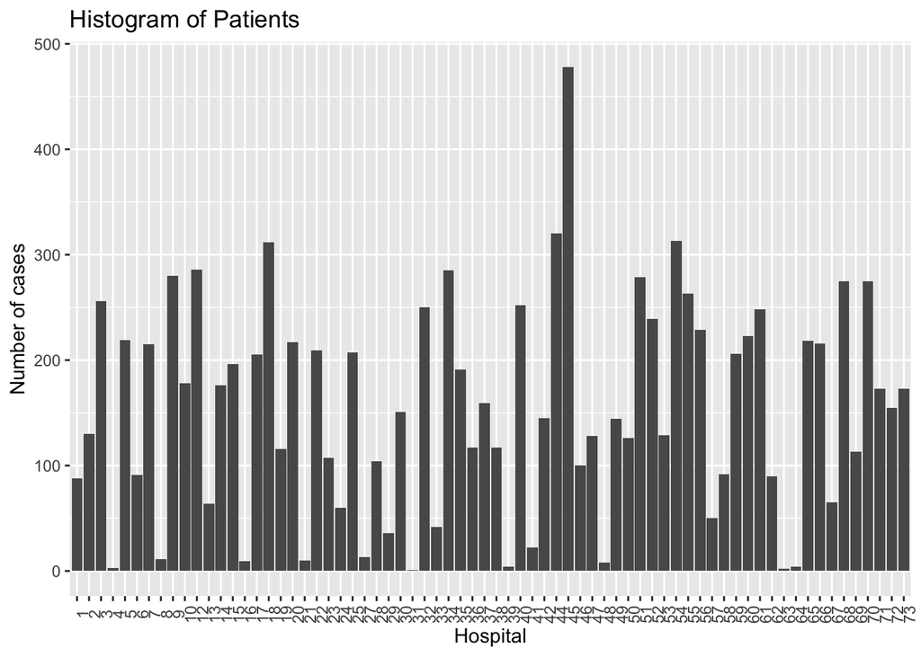

```r
#Site ID as factor
raw_colectomy$site_cid_160801=substr(raw_colectomy$site_cid_160801,2,4)
raw_colectomy$site_cid_160801=as.numeric(raw_colectomy$site_cid_160801)
raw_colectomy$site_cid_160801=as.factor(raw_colectomy$site_cid_160801)

#EDA:
#1.Histogram of cases in each hospital:
library(ggplot2)
hospitals = ggplot(raw_colectomy, aes(x = site_cid_160801)) +
  geom_bar() +
  labs(x = "Hospital", y = "Number of cases", title = "Histogram of Patients") +
  theme(axis.text.x = element_text(angle = 90))
print(hospitals)
```

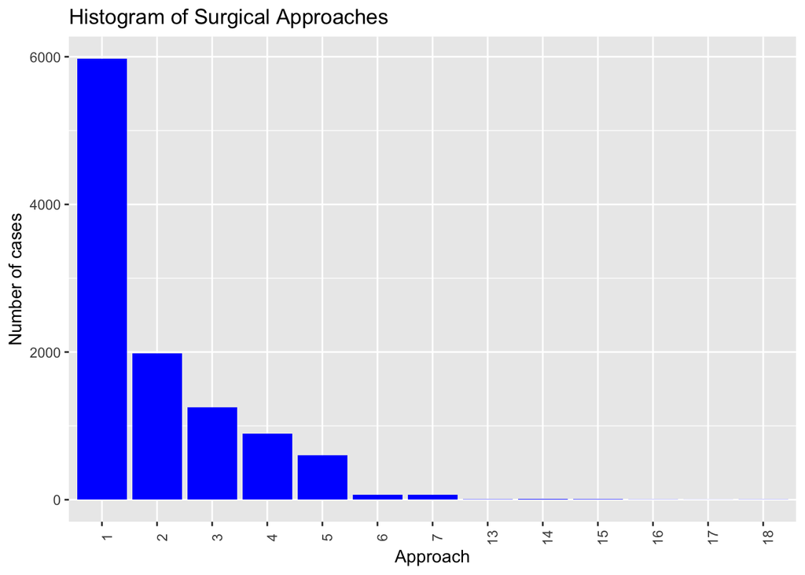

```r
ggplot(raw_colectomy, aes(x = as.factor(surgical_approach))) +
  geom_bar(fill = "blue") +
  labs(x = "Approach", y = "Number of cases", title = 'Histogram of Surgical Approaches') +
  theme(axis.text.x = element_text(angle = 90))
```

```r
table(raw_colectomy$surgical_approach)
```

```
##
##    1    2    3    4    5    6    7   13   14   15   16   17   18
## 5974 1986 1251  891  604   67   67    4   13    6    2    1    2
```

```r
#  1    2    3    4    5    6    7   13   14   15   16   17   18
#5974 1986 1251  891  604   67   67    4   13    6    2    1    2
# 1 for open, 2 for Laparoscopic, 3 for Laparoscopic, Hand-Assisted
# 4 for Laparoscopic, Converted to Open
# 5 for Robotic
# 6 for Robotic, Converted to Open
# 7 for Laparoscopic, Single Port (SIL)
# 13-18 for Other.

#Remove the columns with mostly missing values: (less than 10000 colectomy cases)
colectomy = raw_colectomy;
colectomy.var = logical(ncol(colectomy))
for(i in 1:ncol(colectomy)){
  complete_case = complete.cases(colectomy[,i]);
  complete_case = as.numeric(complete_case)
  if(sum(complete_case) > 10000){
    colectomy.var[i]=TRUE
  }
}
table(colectomy.var) #554 variables removed.
```

```
## colectomy.var
## FALSE  TRUE
##   554   438
```